# Practical Machine Learning - Course Project: Writeup

Sachio Iwamoto

Tuesday, March 17, 2015

## Overview

Six young health participants were asked to perform one set of 10 repetitions of the Unilateral Dumbbell Biceps Curl in five different fashions: exactly according to the specification (Class A), throwing the elbows to the front (Class B), lifting the dumbbell only halfway (Class C), lowering the dumbbell only halfway (Class D) and throwing the hips to the front (Class E). The goal of the project is to predict how well they did the exercise.

The data used for this project come from [Groupware@LES](http://groupware.les.inf.puc-rio.br/har).

## 1.Loading packages and data

At first we load the training and test data in the R datasets package.

```r
library(knitr); library("caret"); library("randomForest")
wd <- getwd()
fileUrl_train <- "https://d396qusza40orc.cloudfront.net/predmachlearn/pml-training.csv"
fileUrl_test <- "https://d396qusza40orc.cloudfront.net/predmachlearn/pml-testing.csv"
file_train <- "pml-training.csv"
file_test <- "pml-testing.csv"
if(!file.exists(file_train)) {
        download.file(fileUrl_train, file_train)
}
if(!file.exists(file_test)) {
        download.file(fileUrl_test, file_test)
}
training <- read.csv(paste(wd, "/", file_train, sep = ""))
testing <- read.csv(paste(wd, "/", file_test, sep = ""))
```

## 2.Basic exploratory data analyses and cleansing

At first we explore data to see its size, the number of variables, data types and missing values for each column in the dataset by running the following R commands. The output of these commands can be found in the Appendix at the end of this report.

```
- dim(training)
- str(training)
- summary(training)
- head(training)
```

A lot of valiables in the training dataset seem to have many NAs, therefore it would be worth to further investigate about NAs so that we can make a decision as to how we handle NAs to reduce the number of predictors.

```r
missing <- sapply(training, function(x) sum(is.na(x)))
summary(as.factor(missing))
```

```
##     0 19216
##    93    67
```

67 variables out of the total 160 have 19,216 NAs, which is approximately 98% of all observations (because 19,216/19,622 = 98%). Thus, these variables have data for only 2% of observations, hence it would be reasonable to exclude them from analysis. The rest of 93 variables have no NAs.

```r
training <- subset(training[,names(missing[missing == 0])])
```

Now, we will need to exclude the same variables from test dataset to run prediction successfully. At first we will quickly explore the test dataset to ensure the right variables to exclude. The output of these commands can be found in the Appendix at the end of this report.

```
- dim(testing)
- str(testing)
- summary(testing)
- head(testing)
```

We found that the test dataset does not have “classe” variable, instead it has “problem_id”. Therefore we make a minor modification to the “missing” vector to use it to remove equiverent valiables from the testing dataset.

```r
missing_test <- missing[names(missing) != "classe"]
testing <- subset(testing[,names(missing_test[missing_test == 0])])
```

Next, in the same way, we will look for variables that don’t have values (i.e. not NA but empty) for many observations and see if it’s reasonable to exclude them from analysis, too.

```r
missing <- sapply(training, function(x) sum(x == ""))
summary(as.factor(missing))
```

```
##     0 19216
##    60    33
```

33 variables out of total 93 have 19,216 values whose length is zero, which is approximately 19,216/19,622 = 98% of all the observations. Hence, we decide to exclude them from analysis, too. The rest of 60 variables have no values whose length is zero (i.e. empty).

```r
training <- subset(training[,names(missing[missing == 0])])
missing_test <- missing[names(missing) != "classe"]
testing <- subset(testing[,names(missing_test[missing_test == 0])])
```

In addition, given the nature of the variables, the following six columns do not need to be part of the predictors. (It’s obvious that row sequence numbers, user names, time stamps, etc. are not related to the quality of exercise.)

```
- X
- user_name
- raw_timestamp_part_1
- raw_timestamp_part_2
- cvtd_timestamp
- new_window
```

```r
training <- subset(training,
                   select = -c(X, user_name, raw_timestamp_part_1,
                               raw_timestamp_part_2, cvtd_timestamp, new_window))
testing <- subset(testing,
                   select = -c(X, user_name, raw_timestamp_part_1,
                               raw_timestamp_part_2, cvtd_timestamp, new_window))
```

## 3.Building a machine learning algorithm

This section explains how the model was built and why I made the choice. Based on the above preliminary data exploration, we reduced the variables from 160 to only 53 excluding “classe”. Now we will build a model using these 53 variables.

There may be several options available to fit the model such as Liner regression (lm), General liner regression (glm), Liner discriminant analysis (lda), random forest, bagging, boosting, etc. As a starter, we will use **random forest** with **k-fold cross validation (k = 3)** and see how accurate its prediction is and if its computation (performance) is efficient enough.

```r
set.seed(1)
folds <- createFolds(y=training$classe, k=3, list=TRUE, returnTrain=TRUE)
sapply(folds,length)
```

```
## Fold1 Fold2 Fold3
## 13080 13081 13083
```

Let’s try to build a model using Fold1 and see the accuracy (error rate). Note that the number of trees grown by the R randomForest function is 500 by default.

```r
trainingset1 <- training[folds[[1]],]
testingset1 <- training[-folds[[1]],]
system.time(fit1 <- randomForest(classe ~ ., data=trainingset1))
```

```
##    user  system elapsed
##   38.91    0.51   39.65
```

```r
pred1 <- predict(fit1, testingset1)
accuracy1 <- sum(testingset1$classe == pred1)/length(pred1)
accuracy1
```

```
## [1] 0.9972485
```

```r
print(fit1)
```

```
##
## Call:
##  randomForest(formula = classe ~ ., data = trainingset1)
##                Type of random forest: classification
##                      Number of trees: 500
## No. of variables tried at each split: 7
##
##         OOB estimate of  error rate: 0.39%
## Confusion matrix:
##      A    B    C    D    E  class.error
## A 3719    1    0    0    0 0.0002688172
## B    9 2519    3    0    0 0.0047412090
## C    0   11 2270    0    0 0.0048224463
## D    0    0   18 2124    2 0.0093283582
## E    0    0    0    7 2397 0.0029118136
```

It took approximately 40 seconds to fit the model and the accurachy is 99.7% or OOB estimate of error rate is 0.39%. Both performance and accuracy are quite acceptable.

## 4.Expected out of sample error

In this section we further examine the expected “out of sample error”. Below shows the confusion matrix of the fit. Also please find the plot that shows how error rate changes as the number of trees grows. The solid black curve is the Out-of-Bag error rate and the other dotted colored lines are the error rate for each “Classe” (A, B, C, D and E).

```r
fit1$confusion
```

```
##      A    B    C    D    E  class.error
## A 3719    1    0    0    0 0.0002688172
## B    9 2519    3    0    0 0.0047412090
## C    0   11 2270    0    0 0.0048224463
## D    0    0   18 2124    2 0.0093283582
## E    0    0    0    7 2397 0.0029118136
```

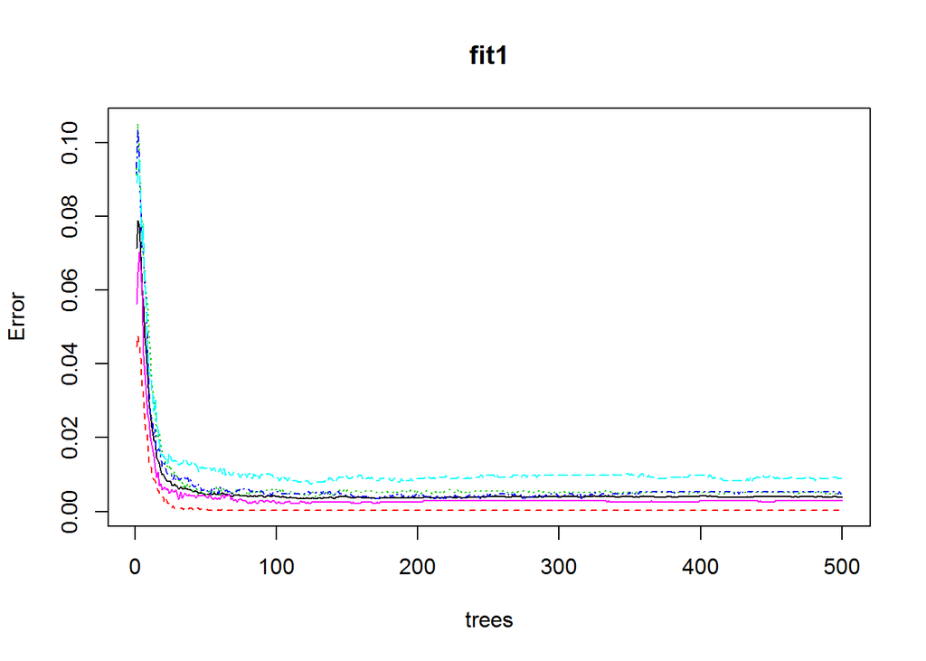

```r
plot(fit1)
```

According to the plot, as the number of trees grow, the error rate decreases until around 30 to 50 trees and then it seems to become flat at well below 2%. Probably tuning the number of trees grown (ntree) could improve the performance (computation) without sacrificing the accuracy. We will see the difference by fitting with “ntree = 50”.

```r
system.time(fit50 <- randomForest(classe ~ ., data=trainingset1, ntree=50))
```

```
##    user  system elapsed
##    4.49    0.17    4.73
```

```r
pred50 <- predict(fit50, testingset1)
accuracy50 <- sum(testingset1$classe == pred50)/length(pred50)
accuracy50
```

```
## [1] 0.9963314
```

```r
print(fit50)
```

```
##
## Call:
##  randomForest(formula = classe ~ ., data = trainingset1, ntree = 50)
##                Type of random forest: classification
##                      Number of trees: 50
## No. of variables tried at each split: 7
##
##         OOB estimate of  error rate: 0.6%
## Confusion matrix:
##      A    B    C    D    E  class.error
## A 3718    1    1    0    0 0.0005376344
## B   14 2504   12    0    1 0.0106677203
## C    0   16 2261    4    0 0.0087680842
## D    0    0   19 2123    2 0.0097947761
## E    0    0    1    8 2395 0.0037437604
```

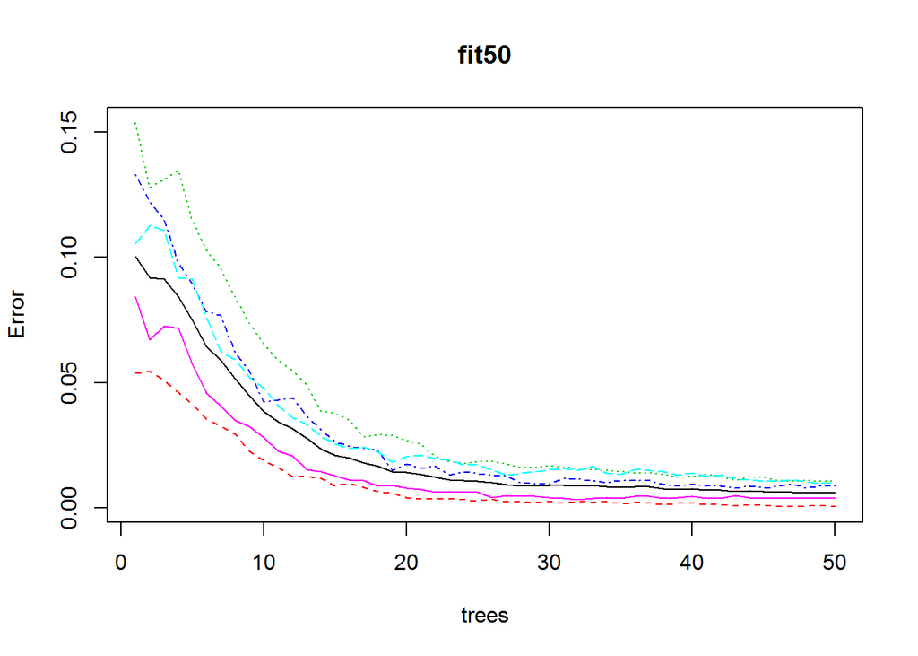

```r
plot(fit50)
```

After changing the number of trees grown from 500 to 50, fitting the model took only 4 second, i.e. 10 times better, yet the accuracy is still 99.6% or or OOB estimate of error rate is 0.6%, which is quite impressive.

By the way, we fitted random forest using “train” function, which is part of Caret package. Here is the command used. We learned that it took approximately 3 hours to compute.

```
"fit <- train(classe ~ ., method="rf", data=trainingset)"
```

## 5.Estimating the error with cross-validation

Given the above results, We are satisfied with both performance and accuracy. We decided not to examine any other modeling techniques such as lm and glm. However, we will futher validate the model using Cross Validation by using Fold2 and Fold3 created above.

```r
trainingset2 <- training[folds[[2]],]
trainingset3 <- training[folds[[3]],]
testingset2 <- training[-folds[[2]],]
testingset3 <- training[-folds[[3]],]
system.time(fit2 <- randomForest(classe ~ ., data=trainingset2, ntree=50))
```

```
##    user  system elapsed
##    3.97    0.03    4.07
```

```r
system.time(fit3 <- randomForest(classe ~ ., data=trainingset3, ntree=50))
```

```
##    user  system elapsed
##    4.07    0.00    4.07
```

The performance to fit the model with “ntree=50” is quite stable around 4 second.

```r
pred2 <- predict(fit2, testingset2)
pred3 <- predict(fit3, testingset3)
accuracy2 <- sum(testingset2$classe == pred2)/length(pred2)
accuracy3 <- sum(testingset3$classe == pred3)/length(pred3)
accuracy2; accuracy3
```

```
## [1] 0.9964837
```

```
## [1] 0.9966356
```

Accuracy seems to be always high around 99.7%.

```r
print(fit2)
```

```
##
## Call:
##  randomForest(formula = classe ~ ., data = trainingset2, ntree = 50)
##                Type of random forest: classification
##                      Number of trees: 50
## No. of variables tried at each split: 7
##
##         OOB estimate of  error rate: 0.48%
## Confusion matrix:
##      A    B    C    D    E  class.error
## A 3719    0    0    0    1 0.0002688172
## B   11 2510    9    1    0 0.0082971158
## C    0   17 2262    2    0 0.0083296800
## D    0    0   16 2127    1 0.0079291045
## E    0    1    0    4 2400 0.0020790021
```

```r
print(fit3)
```

```
##
## Call:
##  randomForest(formula = classe ~ ., data = trainingset3, ntree = 50)
##                Type of random forest: classification
##                      Number of trees: 50
## No. of variables tried at each split: 7
##
##         OOB estimate of  error rate: 0.5%
## Confusion matrix:
##      A    B    C    D    E  class.error
## A 3719    1    0    0    0 0.0002688172
## B   10 2517    5    0    0 0.0059241706
## C    0   12 2265    5    0 0.0074496056
## D    0    0   22 2120    2 0.0111940299
## E    0    1    0    8 2396 0.0037422037
```

OOB estimate of error rate is also always around 0.5%, which is reasonably low.

## 6. Predicting the 20 test cases for assignment submission

Finally, we apply the machine learning algorithm built above to each of the 20 test cases. We use all three models (fit1, fit2 and fit3) and compare the results.

```r
result1 <- predict(fit1, testing)
result2 <- predict(fit2, testing)
result3 <- predict(fit3, testing)
result1; result2; result3
```

```
##  1  2  3  4  5  6  7  8  9 10 11 12 13 14 15 16 17 18 19 20
##  B  A  B  A  A  E  D  B  A  A  B  C  B  A  E  E  A  B  B  B
## Levels: A B C D E
```

```
##  1  2  3  4  5  6  7  8  9 10 11 12 13 14 15 16 17 18 19 20
##  B  A  B  A  A  E  D  B  A  A  B  C  B  A  E  E  A  B  B  B
## Levels: A B C D E
```

```
##  1  2  3  4  5  6  7  8  9 10 11 12 13 14 15 16 17 18 19 20
##  B  A  B  A  A  E  D  B  A  A  B  C  B  A  E  E  A  B  B  B
## Levels: A B C D E
```

Here you see all three results are identical each other. We submitted the assignment and confirmed that the results of all 20 test cases above are in fact correct.

## 7. Appendix

### 7-1. Exploring training data

```r
dim(training)
```

```
## [1] 19622    54
```

```r
str(training)
```

```
## 'data.frame':    19622 obs. of  54 variables:
##  $ num_window          : int  11 11 11 12 12 12 12 12 12 12 ...
##  $ roll_belt           : num  1.41 1.41 1.42 1.48 1.48 1.45 1.42 1.42 1.43 1.45 ...
##  $ pitch_belt          : num  8.07 8.07 8.07 8.05 8.07 8.06 8.09 8.13 8.16 8.17 ...
##  $ yaw_belt            : num  -94.4 -94.4 -94.4 -94.4 -94.4 -94.4 -94.4 -94.4 -94.4 -94.4 ...
##  $ total_accel_belt    : int  3 3 3 3 3 3 3 3 3 3 ...
##  $ gyros_belt_x        : num  0 0.02 0 0.02 0.02 0.02 0.02 0.02 0.02 0.03 ...
##  $ gyros_belt_y        : num  0 0 0 0 0.02 0 0 0 0 0 ...
##  $ gyros_belt_z        : num  -0.02 -0.02 -0.02 -0.03 -0.02 -0.02 -0.02 -0.02 -0.02 0 ...
##  $ accel_belt_x        : int  -21 -22 -20 -22 -21 -21 -22 -22 -20 -21 ...
##  $ accel_belt_y        : int  4 4 5 3 2 4 3 4 2 4 ...
##  $ accel_belt_z        : int  22 22 23 21 24 21 21 21 24 22 ...
##  $ magnet_belt_x       : int  -3 -7 -2 -6 -6 0 -4 -2 1 -3 ...
##  $ magnet_belt_y       : int  599 608 600 604 600 603 599 603 602 609 ...
##  $ magnet_belt_z       : int  -313 -311 -305 -310 -302 -312 -311 -313 -312 -308 ...
```

[output cut: 40 more lines]

```r
summary(training)
```

```
##    num_window      roll_belt        pitch_belt          yaw_belt
##  Min.   :  1.0   Min.   :-28.90   Min.   :-55.8000   Min.   :-180.00
##  1st Qu.:222.0   1st Qu.:  1.10   1st Qu.:  1.7600   1st Qu.: -88.30
##  Median :424.0   Median :113.00   Median :  5.2800   Median : -13.00
##  Mean   :430.6   Mean   : 64.41   Mean   :  0.3053   Mean   : -11.21
##  3rd Qu.:644.0   3rd Qu.:123.00   3rd Qu.: 14.9000   3rd Qu.:  12.90
##  Max.   :864.0   Max.   :162.00   Max.   : 60.3000   Max.   : 179.00
##  total_accel_belt  gyros_belt_x        gyros_belt_y       gyros_belt_z
##  Min.   : 0.00    Min.   :-1.040000   Min.   :-0.64000   Min.   :-1.4600
##  1st Qu.: 3.00    1st Qu.:-0.030000   1st Qu.: 0.00000   1st Qu.:-0.2000
##  Median :17.00    Median : 0.030000   Median : 0.02000   Median :-0.1000
##  Mean   :11.31    Mean   :-0.005592   Mean   : 0.03959   Mean   :-0.1305
##  3rd Qu.:18.00    3rd Qu.: 0.110000   3rd Qu.: 0.11000   3rd Qu.:-0.0200
##  Max.   :29.00    Max.   : 2.220000   Max.   : 0.64000   Max.   : 1.6200
##   accel_belt_x       accel_belt_y     accel_belt_z     magnet_belt_x
##  Min.   :-120.000   Min.   :-69.00   Min.   :-275.00   Min.   :-52.0
##  1st Qu.: -21.000   1st Qu.:  3.00   1st Qu.:-162.00   1st Qu.:  9.0
##  Median : -15.000   Median : 35.00   Median :-152.00   Median : 35.0
##  Mean   :  -5.595   Mean   : 30.15   Mean   : -72.59   Mean   : 55.6
##  3rd Qu.:  -5.000   3rd Qu.: 61.00   3rd Qu.:  27.00   3rd Qu.: 59.0
##  Max.   :  85.000   Max.   :164.00   Max.   : 105.00   Max.   :485.0
##  magnet_belt_y   magnet_belt_z       roll_arm         pitch_arm
##  Min.   :354.0   Min.   :-623.0   Min.   :-180.00   Min.   :-88.800
##  1st Qu.:581.0   1st Qu.:-375.0   1st Qu.: -31.77   1st Qu.:-25.900
##  Median :601.0   Median :-320.0   Median :   0.00   Median :  0.000
##  Mean   :593.7   Mean   :-345.5   Mean   :  17.83   Mean   : -4.612
##  3rd Qu.:610.0   3rd Qu.:-306.0   3rd Qu.:  77.30   3rd Qu.: 11.200
##  Max.   :673.0   Max.   : 293.0   Max.   : 180.00   Max.   : 88.500
##     yaw_arm          total_accel_arm  gyros_arm_x        gyros_arm_y
##  Min.   :-180.0000   Min.   : 1.00   Min.   :-6.37000   Min.   :-3.4400
##  1st Qu.: -43.1000   1st Qu.:17.00   1st Qu.:-1.33000   1st Qu.:-0.8000
##  Median :   0.0000   Median :27.00   Median : 0.08000   Median :-0.2400
##  Mean   :  -0.6188   Mean   :25.51   Mean   : 0.04277   Mean   :-0.2571
##  3rd Qu.:  45.8750   3rd Qu.:33.00   3rd Qu.: 1.57000   3rd Qu.: 0.1400
##  Max.   : 180.0000   Max.   :66.00   Max.   : 4.87000   Max.   : 2.8400
##   gyros_arm_z       accel_arm_x       accel_arm_y      accel_arm_z
##  Min.   :-2.3300   Min.   :-404.00   Min.   :-318.0   Min.   :-636.00
##  1st Qu.:-0.0700   1st Qu.:-242.00   1st Qu.: -54.0   1st Qu.:-143.00
##  Median : 0.2300   Median : -44.00   Median :  14.0   Median : -47.00
##  Mean   : 0.2695   Mean   : -60.24   Mean   :  32.6   Mean   : -71.25
```

[output cut: 50 more lines]

```
##  Max.   :311.00000   Max.   :231.0000   Max.   : 477.00   Max.   : 923.0
##  accel_forearm_z   magnet_forearm_x  magnet_forearm_y magnet_forearm_z
##  Min.   :-446.00   Min.   :-1280.0   Min.   :-896.0   Min.   :-973.0
##  1st Qu.:-182.00   1st Qu.: -616.0   1st Qu.:   2.0   1st Qu.: 191.0
##  Median : -39.00   Median : -378.0   Median : 591.0   Median : 511.0
##  Mean   : -55.29   Mean   : -312.6   Mean   : 380.1   Mean   : 393.6
##  3rd Qu.:  26.00   3rd Qu.:  -73.0   3rd Qu.: 737.0   3rd Qu.: 653.0
##  Max.   : 291.00   Max.   :  672.0   Max.   :1480.0   Max.   :1090.0
##  classe
##  A:5580
##  B:3797
##  C:3422
##  D:3216
##  E:3607
##
```

```r
head(training)
```

```
##   num_window roll_belt pitch_belt yaw_belt total_accel_belt gyros_belt_x
## 1         11      1.41       8.07    -94.4                3         0.00
## 2         11      1.41       8.07    -94.4                3         0.02
## 3         11      1.42       8.07    -94.4                3         0.00
## 4         12      1.48       8.05    -94.4                3         0.02
## 5         12      1.48       8.07    -94.4                3         0.02
## 6         12      1.45       8.06    -94.4                3         0.02
##   gyros_belt_y gyros_belt_z accel_belt_x accel_belt_y accel_belt_z
## 1         0.00        -0.02          -21            4           22
## 2         0.00        -0.02          -22            4           22
## 3         0.00        -0.02          -20            5           23
## 4         0.00        -0.03          -22            3           21
## 5         0.02        -0.02          -21            2           24
## 6         0.00        -0.02          -21            4           21
##   magnet_belt_x magnet_belt_y magnet_belt_z roll_arm pitch_arm yaw_arm
```

[output cut: 69 more lines]

### 7-1. Exploring testing data

```r
dim(testing)
```

```
## [1] 20 53
```

```r
str(testing)
```

```
## 'data.frame':    20 obs. of  53 variables:
##  $ num_window          : int  74 431 439 194 235 504 485 440 323 664 ...
##  $ roll_belt           : num  123 1.02 0.87 125 1.35 -5.92 1.2 0.43 0.93 114 ...
##  $ pitch_belt          : num  27 4.87 1.82 -41.6 3.33 1.59 4.44 4.15 6.72 22.4 ...
##  $ yaw_belt            : num  -4.75 -88.9 -88.5 162 -88.6 -87.7 -87.3 -88.5 -93.7 -13.1 ...
##  $ total_accel_belt    : int  20 4 5 17 3 4 4 4 4 18 ...
##  $ gyros_belt_x        : num  -0.5 -0.06 0.05 0.11 0.03 0.1 -0.06 -0.18 0.1 0.14 ...
##  $ gyros_belt_y        : num  -0.02 -0.02 0.02 0.11 0.02 0.05 0 -0.02 0 0.11 ...
##  $ gyros_belt_z        : num  -0.46 -0.07 0.03 -0.16 0 -0.13 0 -0.03 -0.02 -0.16 ...
##  $ accel_belt_x        : int  -38 -13 1 46 -8 -11 -14 -10 -15 -25 ...
##  $ accel_belt_y        : int  69 11 -1 45 4 -16 2 -2 1 63 ...
##  $ accel_belt_z        : int  -179 39 49 -156 27 38 35 42 32 -158 ...
##  $ magnet_belt_x       : int  -13 43 29 169 33 31 50 39 -6 10 ...
##  $ magnet_belt_y       : int  581 636 631 608 566 638 622 635 600 601 ...
##  $ magnet_belt_z       : int  -382 -309 -312 -304 -418 -291 -315 -305 -302 -330 ...
```

[output cut: 39 more lines]

```r
summary(testing)
```

```
##    num_window      roll_belt          pitch_belt         yaw_belt
##  Min.   : 48.0   Min.   : -5.9200   Min.   :-41.600   Min.   :-93.70
##  1st Qu.:250.0   1st Qu.:  0.9075   1st Qu.:  3.013   1st Qu.:-88.62
##  Median :384.5   Median :  1.1100   Median :  4.655   Median :-87.85
##  Mean   :379.6   Mean   : 31.3055   Mean   :  5.824   Mean   :-59.30
##  3rd Qu.:467.0   3rd Qu.: 32.5050   3rd Qu.:  6.135   3rd Qu.:-63.50
##  Max.   :859.0   Max.   :129.0000   Max.   : 27.800   Max.   :162.00
##  total_accel_belt  gyros_belt_x     gyros_belt_y     gyros_belt_z
##  Min.   : 2.00    Min.   :-0.500   Min.   :-0.050   Min.   :-0.4800
##  1st Qu.: 3.00    1st Qu.:-0.070   1st Qu.:-0.005   1st Qu.:-0.1375
##  Median : 4.00    Median : 0.020   Median : 0.000   Median :-0.0250
##  Mean   : 7.55    Mean   :-0.045   Mean   : 0.010   Mean   :-0.1005
##  3rd Qu.: 8.00    3rd Qu.: 0.070   3rd Qu.: 0.020   3rd Qu.: 0.0000
##  Max.   :21.00    Max.   : 0.240   Max.   : 0.110   Max.   : 0.0500
##   accel_belt_x     accel_belt_y     accel_belt_z     magnet_belt_x
##  Min.   :-48.00   Min.   :-16.00   Min.   :-187.00   Min.   :-13.00
##  1st Qu.:-19.00   1st Qu.:  2.00   1st Qu.: -24.00   1st Qu.:  5.50
##  Median :-13.00   Median :  4.50   Median :  27.00   Median : 33.50
##  Mean   :-13.50   Mean   : 18.35   Mean   : -17.60   Mean   : 35.15
##  3rd Qu.: -8.75   3rd Qu.: 25.50   3rd Qu.:  38.25   3rd Qu.: 46.25
##  Max.   : 46.00   Max.   : 72.00   Max.   :  49.00   Max.   :169.00
##  magnet_belt_y   magnet_belt_z       roll_arm         pitch_arm
##  Min.   :566.0   Min.   :-426.0   Min.   :-137.00   Min.   :-63.800
##  1st Qu.:578.5   1st Qu.:-398.5   1st Qu.:   0.00   1st Qu.: -9.188
##  Median :600.5   Median :-313.5   Median :   0.00   Median :  0.000
##  Mean   :601.5   Mean   :-346.9   Mean   :  16.42   Mean   : -3.950
##  3rd Qu.:631.2   3rd Qu.:-305.0   3rd Qu.:  71.53   3rd Qu.:  3.465
##  Max.   :638.0   Max.   :-291.0   Max.   : 152.00   Max.   : 55.000
##     yaw_arm        total_accel_arm  gyros_arm_x      gyros_arm_y
##  Min.   :-167.00   Min.   : 3.00   Min.   :-3.710   Min.   :-2.0900
##  1st Qu.: -60.15   1st Qu.:20.25   1st Qu.:-0.645   1st Qu.:-0.6350
##  Median :   0.00   Median :29.50   Median : 0.020   Median :-0.0400
##  Mean   :  -2.80   Mean   :26.40   Mean   : 0.077   Mean   :-0.1595
##  3rd Qu.:  25.50   3rd Qu.:33.25   3rd Qu.: 1.248   3rd Qu.: 0.2175
##  Max.   : 178.00   Max.   :44.00   Max.   : 3.660   Max.   : 1.8500
##   gyros_arm_z       accel_arm_x      accel_arm_y      accel_arm_z
##  Min.   :-0.6900   Min.   :-341.0   Min.   :-65.00   Min.   :-404.00
##  1st Qu.:-0.1800   1st Qu.:-277.0   1st Qu.: 52.25   1st Qu.:-128.50
##  Median :-0.0250   Median :-194.5   Median :112.00   Median : -83.50
##  Mean   : 0.1205   Mean   :-134.6   Mean   :103.10   Mean   : -87.85
```

[output cut: 43 more lines]

```
##  Max.   :47.00       Max.   : 1.3800   Max.   : 4.2600   Max.   : 1.8000
##  accel_forearm_x  accel_forearm_y  accel_forearm_z  magnet_forearm_x
##  Min.   :-212.0   Min.   :-331.0   Min.   :-282.0   Min.   :-714.0
##  1st Qu.:-114.8   1st Qu.:   8.5   1st Qu.:-199.0   1st Qu.:-427.2
##  Median :  86.0   Median : 138.0   Median :-148.5   Median :-189.5
##  Mean   :  38.8   Mean   : 125.3   Mean   : -93.7   Mean   :-159.2
##  3rd Qu.: 166.2   3rd Qu.: 268.0   3rd Qu.: -31.0   3rd Qu.:  41.5
##  Max.   : 232.0   Max.   : 406.0   Max.   : 179.0   Max.   : 532.0
##  magnet_forearm_y magnet_forearm_z
##  Min.   :-787.0   Min.   :-32.0
##  1st Qu.:-328.8   1st Qu.:275.2
##  Median : 487.0   Median :491.5
##  Mean   : 191.8   Mean   :460.2
##  3rd Qu.: 720.8   3rd Qu.:661.5
##  Max.   : 800.0   Max.   :884.0
```

```r
head(testing)
```

```
##   num_window roll_belt pitch_belt yaw_belt total_accel_belt gyros_belt_x
## 1         74    123.00      27.00    -4.75               20        -0.50
## 2        431      1.02       4.87   -88.90                4        -0.06
## 3        439      0.87       1.82   -88.50                5         0.05
## 4        194    125.00     -41.60   162.00               17         0.11
## 5        235      1.35       3.33   -88.60                3         0.03
## 6        504     -5.92       1.59   -87.70                4         0.10
##   gyros_belt_y gyros_belt_z accel_belt_x accel_belt_y accel_belt_z
## 1        -0.02        -0.46          -38           69         -179
## 2        -0.02        -0.07          -13           11           39
## 3         0.02         0.03            1           -1           49
## 4         0.11        -0.16           46           45         -156
## 5         0.02         0.00           -8            4           27
## 6         0.05        -0.13          -11          -16           38
##   magnet_belt_x magnet_belt_y magnet_belt_z roll_arm pitch_arm yaw_arm
```

[output cut: 69 more lines]